# Amazon Fine Food Reviews Analysis

Data Source: https://www.kaggle.com/snap/amazon-fine-food-reviews

EDA: https://nycdatascience.com/blog/student-works/amazon-fine-foods-visualization/

The Amazon Fine Food Reviews dataset consists of reviews of fine foods from Amazon.

Number of reviews: 568,454  
Number of users: 256,059  
Number of products: 74,258  
Timespan: Oct 1999 - Oct 2012  
Number of Attributes/Columns in data: 10

Attribute Information:

1. Id
2. ProductId - unique identifier for the product
3. UserId - unqiue identifier for the user
4. ProfileName
5. HelpfulnessNumerator - number of users who found the review helpful
6. HelpfulnessDenominator - number of users who indicated whether they found the review helpful or not
7. Score - rating between 1 and 5
8. Time - timestamp for the review
9. Summary - brief summary of the review
10. Text - text of the review

#### Objective:

Given a review, determine whether the review is positive (rating of 4 or 5) or negative (rating of 1 or 2).

[Q] How to determine if a review is positive or negative?  
[Ans] We could use Score/Rating. A rating of 4 or 5 can be cosnidered as a positive review. A rating of 1 or 2 can be considered as negative one. A review of rating 3 is considered nuetral and such reviews are ignored from our analysis. This is an approximate and proxy way of determining the polarity (positivity/negativity) of a review.

# [1]. Reading Data

## [1.1] Loading the data

The dataset is available in two forms

1. .csv file
2. SQLite Database

In order to load the data, We have used the SQLITE dataset as it is easier to query the data and visualise the data efficiently.

Here as we only want to get the global sentiment of the recommendations (positive or negative), we will purposefully ignore all Scores equal to 3. If the score is above 3, then the recommendation wil be set to "positive". Otherwise, it will be set to "negative".

```python
%matplotlib inline
import warnings
warnings.filterwarnings("ignore")


import sqlite3
import pandas as pd
import numpy as np
import nltk
import string
import matplotlib.pyplot as plt
import seaborn as sns
from sklearn.feature_extraction.text import TfidfTransformer
from sklearn.feature_extraction.text import TfidfVectorizer

from sklearn.feature_extraction.text import CountVectorizer
from sklearn.metrics import confusion_matrix
from sklearn import metrics
from sklearn.metrics import roc_curve, auc
from nltk.stem.porter import PorterStemmer
from google.colab import drive


import re
# Tutorial about Python regular expressions: https://pymotw.com/2/re/
import string
from nltk.corpus import stopwords
from nltk.stem import PorterStemmer
from nltk.stem.wordnet import WordNetLemmatizer

from gensim.models import Word2Vec
from gensim.models import KeyedVectors
import pickle

from tqdm import tqdm
import os
!pip install pandasql
import pandasql as ps
!pip install kaggle
```

```python
#upload the credentials of the kaggle account
from google.colab import files
files.upload()
```

```
Saving kaggle.json to kaggle.json
```

[output not shown]

```python
#before importing the dataset we want to use this code
# The Kaggle API client expects this file to be in ~/.kaggle,
!mkdir -p ~/.kaggle
!cp kaggle.json ~/.kaggle/

# This permissions change avoids a warning on Kaggle tool startup.
!chmod 600 ~/.kaggle/kaggle.json
```

```python
!ls
```

```
kaggle.json  sample_data
```

```python
#import the dataset we want to use for our project
!kaggle datasets download -d snap/amazon-fine-food-reviews --force
```

```
Downloading amazon-fine-food-reviews.zip to /content
 98% 246M/251M [00:02<00:00, 135MB/s]
100% 251M/251M [00:02<00:00, 110MB/s]
```

```python
!ls
```

```
amazon-fine-food-reviews.zip  kaggle.json  sample_data
```

```python
!unzip amazon-fine-food-reviews.zip
```

```
Archive:  amazon-fine-food-reviews.zip
  inflating: Reviews.csv
  inflating: database.sqlite
  inflating: hashes.txt
```

```python
!ls
```

```
amazon-fine-food-reviews.zip  hashes.txt   Reviews.csv
database.sqlite		      kaggle.json  sample_data
```

```python
# using SQLite Table to read data.
con = sqlite3.connect('database.sqlite')

# filtering only positive and negative reviews i.e.
# not taking into consideration those reviews with Score=3
# SELECT * FROM Reviews WHERE Score != 3 LIMIT 500000, will give top 500000 data points
# you can change the number to any other number based on your computing power

filtered_data = pd.read_sql_query(""" SELECT * FROM Reviews WHERE Score != 3 LIMIT 70000""", con)
# for tsne assignment you can take 5k data points

#filtered_data = pd.read_sql_query(""" SELECT * FROM Reviews WHERE Score != 3 LIMIT 5000""", con)

# Give reviews with Score>3 a positive rating(1), and reviews with a score<3 a negative rating(0).
def partition(x):
    if x < 3:
        return 0
    return 1

#changing reviews with score less than 3 to be positive and vice-versa
actualScore = filtered_data['Score']
positiveNegative = actualScore.map(partition)
filtered_data['Score'] = positiveNegative
print("Number of data points in our data", filtered_data.shape)
filtered_data.head(5)
```

```
Number of data points in our data (70000, 10)
```

|  | Id | ProductId | UserId | ProfileName | HelpfulnessNumerator | HelpfulnessDenominator | Score | Time | Summary | Text |
| --- | --- | --- | --- | --- | --- | --- | --- | --- | --- | --- |
| 0 | 1 | B001E4KFG0 | A3SGXH7AUHU8GW | delmartian | 1 | 1 | 1 | 1303862400 | Good Quality Dog Food | I have bought several of the Vitality canned d... |
| 1 | 2 | B00813GRG4 | A1D87F6ZCVE5NK | dll pa | 0 | 0 | 0 | 1346976000 | Not as Advertised | Product arrived labeled as Jumbo Salted Peanut... |
| 2 | 3 | B000LQOCH0 | ABXLMWJIXXAIN | Natalia Corres "Natalia Corres" | 1 | 1 | 1 | 1219017600 | "Delight" says it all | This is a confection that has been around a fe... |
| 3 | 4 | B000UA0QIQ | A395BORC6FGVXV | Karl | 3 | 3 | 0 | 1307923200 | Cough Medicine | If you are looking for the secret ingredient i... |
| 4 | 5 | B006K2ZZ7K | A1UQRSCLF8GW1T | Michael D. Bigham "M. Wassir" | 0 | 0 | 1 | 1350777600 | Great taffy | Great taffy at a great price. There was a wid... |

```python
display = pd.read_sql_query("""
SELECT UserId, ProductId, ProfileName, Time, Score, Text, COUNT(*)
FROM Reviews
GROUP BY UserId
HAVING COUNT(*)>1
""", con)
```

```python
print(display.shape)
display.head()
```

```
(80668, 7)
```

|  | UserId | ProductId | ProfileName | Time | Score | Text | COUNT(*) |
| --- | --- | --- | --- | --- | --- | --- | --- |
| 0 | #oc-R115TNMSPFT9I7 | B007Y59HVM | Breyton | 1331510400 | 2 | Overall its just OK when considering the price... | 2 |
| 1 | #oc-R11D9D7SHXIJB9 | B005HG9ET0 | Louis E. Emory "hoppy" | 1342396800 | 5 | My wife has recurring extreme muscle spasms, u... | 3 |
| 2 | #oc-R11DNU2NBKQ23Z | B007Y59HVM | Kim Cieszykowski | 1348531200 | 1 | This coffee is horrible and unfortunately not ... | 2 |
| 3 | #oc-R11O5J5ZVQE25C | B005HG9ET0 | Penguin Chick | 1346889600 | 5 | This will be the bottle that you grab from the... | 3 |
| 4 | #oc-R12KPBODL2B5ZD | B007OSBE1U | Christopher P. Presta | 1348617600 | 1 | I didnt like this coffee. Instead of telling y... | 2 |

```python
display[display['UserId']=='#oc-R11D9D7SHXIJB9']
```

|  | UserId | ProductId | ProfileName | Time | Score | Text | COUNT(*) |
| --- | --- | --- | --- | --- | --- | --- | --- |
| 1 | #oc-R11D9D7SHXIJB9 | B005HG9ET0 | Louis E. Emory "hoppy" | 1342396800 | 5 | My wife has recurring extreme muscle spasms, u... | 3 |

```python
display['COUNT(*)'].sum()
```

```
393063
```

# [2] Exploratory Data Analysis

## [2.1] Data Cleaning: Deduplication

It is observed (as shown in the table below) that the reviews data had many duplicate entries. Hence it was necessary to remove duplicates in order to get unbiased results for the analysis of the data. Following is an example:

```python
display= pd.read_sql_query("""
SELECT *
FROM Reviews
WHERE Score != 3 AND UserId="AR5J8UI46CURR"
ORDER BY ProductID
""", con)
display.head()
```

|  | Id | ProductId | UserId | ProfileName | HelpfulnessNumerator | HelpfulnessDenominator | Score | Time | Summary | Text |
| --- | --- | --- | --- | --- | --- | --- | --- | --- | --- | --- |
| 0 | 78445 | B000HDL1RQ | AR5J8UI46CURR | Geetha Krishnan | 2 | 2 | 5 | 1199577600 | LOACKER QUADRATINI VANILLA WAFERS | DELICIOUS WAFERS. I FIND THAT EUROPEAN WAFERS ... |
| 1 | 138317 | B000HDOPYC | AR5J8UI46CURR | Geetha Krishnan | 2 | 2 | 5 | 1199577600 | LOACKER QUADRATINI VANILLA WAFERS | DELICIOUS WAFERS. I FIND THAT EUROPEAN WAFERS ... |
| 2 | 138277 | B000HDOPYM | AR5J8UI46CURR | Geetha Krishnan | 2 | 2 | 5 | 1199577600 | LOACKER QUADRATINI VANILLA WAFERS | DELICIOUS WAFERS. I FIND THAT EUROPEAN WAFERS ... |
| 3 | 73791 | B000HDOPZG | AR5J8UI46CURR | Geetha Krishnan | 2 | 2 | 5 | 1199577600 | LOACKER QUADRATINI VANILLA WAFERS | DELICIOUS WAFERS. I FIND THAT EUROPEAN WAFERS ... |
| 4 | 155049 | B000PAQ75C | AR5J8UI46CURR | Geetha Krishnan | 2 | 2 | 5 | 1199577600 | LOACKER QUADRATINI VANILLA WAFERS | DELICIOUS WAFERS. I FIND THAT EUROPEAN WAFERS ... |

As it can be seen above that same user has multiple reviews with same values for HelpfulnessNumerator, HelpfulnessDenominator, Score, Time, Summary and Text and on doing analysis it was found that  
ProductId=B000HDOPZG was Loacker Quadratini Vanilla Wafer Cookies, 8.82-Ounce Packages (Pack of 8)  
ProductId=B000HDL1RQ was Loacker Quadratini Lemon Wafer Cookies, 8.82-Ounce Packages (Pack of 8) and so on

It was inferred after analysis that reviews with same parameters other than ProductId belonged to the same product just having different flavour or quantity. Hence in order to reduce redundancy it was decided to eliminate the rows having same parameters.

The method used for the same was that we first sort the data according to ProductId and then just keep the first similar product review and delelte the others. for eg. in the above just the review for ProductId=B000HDL1RQ remains. This method ensures that there is only one representative for each product and deduplication without sorting would lead to possibility of different representatives still existing for the same product.

```python
#Sorting data according to ProductId in ascending order
sorted_data=filtered_data.sort_values('ProductId', axis=0, ascending=True, inplace=False, kind='quicksort', na_position='last')
```

```python
#Deduplication of entries
final=sorted_data.drop_duplicates(subset={"UserId","ProfileName","Time","Text"}, keep='first', inplace=False)
final.shape
```

```
(62864, 10)
```

```python
#Checking to see how much % of data still remains
(final['Id'].size*1.0)/(filtered_data['Id'].size*1.0)*100
```

```
89.80571428571429
```

**Observation:-** It was also seen that in two rows given below the value of HelpfulnessNumerator is greater than HelpfulnessDenominator which is not practically possible hence these two rows too are removed from calcualtions

```python
display= pd.read_sql_query("""
SELECT *
FROM Reviews
WHERE Score != 3 AND Id=44737 OR Id=64422
ORDER BY ProductID
""", con)

display.head()
```

|  | Id | ProductId | UserId | ProfileName | HelpfulnessNumerator | HelpfulnessDenominator | Score | Time | Summary | Text |
| --- | --- | --- | --- | --- | --- | --- | --- | --- | --- | --- |
| 0 | 64422 | B000MIDROQ | A161DK06JJMCYF | J. E. Stephens "Jeanne" | 3 | 1 | 5 | 1224892800 | Bought This for My Son at College | My son loves spaghetti so I didn't hesitate or... |
| 1 | 44737 | B001EQ55RW | A2V0I904FH7ABY | Ram | 3 | 2 | 4 | 1212883200 | Pure cocoa taste with crunchy almonds inside | It was almost a 'love at first bite' - the per... |

```python
final=final[final.HelpfulnessNumerator<=final.HelpfulnessDenominator]
```

```python
#Before starting the next phase of preprocessing lets see the number of entries left
print(final.shape)

#How many positive and negative reviews are present in our dataset?
final['Score'].value_counts()
```

```
(62862, 10)
```

```
1    52600
0    10262
Name: Score, dtype: int64
```

# [3] Preprocessing

## [3.1]. Preprocessing Review Text

Now that we have finished deduplication our data requires some preprocessing before we go on further with analysis and making the prediction model.

After which we collect the words used to describe positive and negative reviews

```python
#Finding the reviews which contains URLs in it.
def Find_Url_In_Review(reviews = [], *args):
    count = 0;
    store5Text = {}
    for idx, val in enumerate(reviews):
        text = re.findall('https?://(?:[-\w.]|(?:%[\da-fA-F]{2}))+', val)
        if(text):
            store5Text[idx] = text
            count+=1
            if(count == 25):
                break

    return store5Text

lst = final['Text'].values.tolist()
print(Find_Url_In_Review(lst))
```

```
{3: ['http://www.amazon.com'], 158: ['http://www.consumeraffairs.com'], 179: ['http://www.amazon.com', 'http://www.amazon.com', 'http://www.amazon.com'], 219: ['http://www.amazon.com'], 251: ['http://www.amazon.com'], 270: ['http://www.amazon.com'], 341: ['http://www.amazon.com'], 543: ['http://www.…
```

```python
# printing some random reviews
sent_179 = final['Text'].values[179]
print(sent_179)
print("="*50)

sent_158 = final['Text'].values[158]
print(sent_158)
print("="*50)

sent_1264 = final['Text'].values[1264]
print(sent_1264)
print("="*50)

sent_1281 = final['Text'].values[1281]
print(sent_1281)
print("="*50)
```

```
These wholesome treats are only 1 or 2 calories per biscotti "crouton." My 50 pound dog has a weight problem, and these are the only treats I can use to reward him for obedience multiple times a day.<br /><br />The biscotti don't crumble in my  pocket on a walk, and my dog even sniffs my pockets at …
==================================================
I used to be a fan of Canidae, but after $2k in recent vet bills and a very sick dog, I found out there is a HUGE amount of Consumer Affairs complaints about this company.<br /><br />After blood work, ultrasound and many other tests trying to figure out why my dog wasn't eating, was throwing up on t…
==================================================
Green chili sauces tend to be milder than their red companions, and this "Castillo Salsa Habanera - Green" is no exception.  It has a nice, tiny little kick to it, but it is mild enough that I could just pour it straight into my mouth.<br /><br />So, unless you don't have much tolerance for heat, yo…
==================================================
QUALITY<br />In my opinion, having used a dozen or so brands of olive oil, Colavita is simply the best reasonably priced olive oil which is widely available.  I've been using Colavita for several years now, and have never been dissappointed.  Colavita is excellent quality, dependable, and reasonably…
==================================================
```

```python
# remove urls from text python: https://stackoverflow.com/a/40823105/4084039
sent_179 = re.sub(r"http\S+", "", sent_179)
sent_158 = re.sub(r"http\S+", "", sent_158)
sent_1264 = re.sub(r"http\S+", "", sent_1264)
sent_1281 = re.sub(r"http\S+", "", sent_1281)

print(sent_179)
print("="*50)
print(sent_158)
print("="*50)
print(sent_1264)
print("="*50)
print(sent_1281)
print("="*50)
```

```
These wholesome treats are only 1 or 2 calories per biscotti "crouton." My 50 pound dog has a weight problem, and these are the only treats I can use to reward him for obedience multiple times a day.<br /><br />The biscotti don't crumble in my  pocket on a walk, and my dog even sniffs my pockets at …
==================================================
I used to be a fan of Canidae, but after $2k in recent vet bills and a very sick dog, I found out there is a HUGE amount of Consumer Affairs complaints about this company.<br /><br />After blood work, ultrasound and many other tests trying to figure out why my dog wasn't eating, was throwing up on t…
==================================================
Green chili sauces tend to be milder than their red companions, and this "Castillo Salsa Habanera - Green" is no exception.  It has a nice, tiny little kick to it, but it is mild enough that I could just pour it straight into my mouth.<br /><br />So, unless you don't have much tolerance for heat, yo…
==================================================
QUALITY<br />In my opinion, having used a dozen or so brands of olive oil, Colavita is simply the best reasonably priced olive oil which is widely available.  I've been using Colavita for several years now, and have never been dissappointed.  Colavita is excellent quality, dependable, and reasonably…
==================================================
```

```python
# https://stackoverflow.com/questions/16206380/python-beautifulsoup-how-to-remove-all-tags-from-an-element
from bs4 import BeautifulSoup



soup = BeautifulSoup(sent_179, 'lxml')
text = soup.get_text()
print(text)
print("="*50)

soup = BeautifulSoup(sent_158, 'lxml')
text = soup.get_text()
print(text)
print("="*50)

soup = BeautifulSoup(sent_1264, 'lxml')
text = soup.get_text()
print(text)
print("="*50)

soup = BeautifulSoup(sent_1281, 'lxml')
text = soup.get_text()
print(text)
```

```
These wholesome treats are only 1 or 2 calories per biscotti "crouton." My 50 pound dog has a weight problem, and these are the only treats I can use to reward him for obedience multiple times a day.The biscotti don't crumble in my  pocket on a walk, and my dog even sniffs my pockets at home to ask …
==================================================
I used to be a fan of Canidae, but after $2k in recent vet bills and a very sick dog, I found out there is a HUGE amount of Consumer Affairs complaints about this company.After blood work, ultrasound and many other tests trying to figure out why my dog wasn't eating, was throwing up on the rare occa…
==================================================
Green chili sauces tend to be milder than their red companions, and this "Castillo Salsa Habanera - Green" is no exception.  It has a nice, tiny little kick to it, but it is mild enough that I could just pour it straight into my mouth.So, unless you don't have much tolerance for heat, you are buying…
==================================================
QUALITYIn my opinion, having used a dozen or so brands of olive oil, Colavita is simply the best reasonably priced olive oil which is widely available.  I've been using Colavita for several years now, and have never been dissappointed.  Colavita is excellent quality, dependable, and reasonably price…
```

```python
# https://stackoverflow.com/a/47091490/4084039
# Method will replace Contracted words to normal words.
import re

def decontracted(phrase):
    # specific
    phrase = re.sub(r"won't", "will not", phrase)
    phrase = re.sub(r"can\'t", "can not", phrase)

    # general
    phrase = re.sub(r"n\'t", " not", phrase)
    phrase = re.sub(r"\'re", " are", phrase)
    phrase = re.sub(r"\'s", " is", phrase)
    phrase = re.sub(r"\'d", " would", phrase)
    phrase = re.sub(r"\'ll", " will", phrase)
    phrase = re.sub(r"\'t", " not", phrase)
    phrase = re.sub(r"\'ve", " have", phrase)
    phrase = re.sub(r"\'m", " am", phrase)
    return phrase
```

```python
sent_179 = decontracted(sent_179)
sent_158 = decontracted(sent_158)
sent_1264 = decontracted(sent_1264)
sent_1281 = decontracted(sent_1281)
print(sent_179)
print("="*50)
print(sent_158)
print("="*50)
print(sent_1264)
print("="*50)
print(sent_1281)
print("="*50)
```

```
These wholesome treats are only 1 or 2 calories per biscotti "crouton." My 50 pound dog has a weight problem, and these are the only treats I can use to reward him for obedience multiple times a day.<br /><br />The biscotti do not crumble in my  pocket on a walk, and my dog even sniffs my pockets at…
==================================================
I used to be a fan of Canidae, but after $2k in recent vet bills and a very sick dog, I found out there is a HUGE amount of Consumer Affairs complaints about this company.<br /><br />After blood work, ultrasound and many other tests trying to figure out why my dog was not eating, was throwing up on …
==================================================
Green chili sauces tend to be milder than their red companions, and this "Castillo Salsa Habanera - Green" is no exception.  It has a nice, tiny little kick to it, but it is mild enough that I could just pour it straight into my mouth.<br /><br />So, unless you do not have much tolerance for heat, y…
==================================================
QUALITY<br />In my opinion, having used a dozen or so brands of olive oil, Colavita is simply the best reasonably priced olive oil which is widely available.  I have been using Colavita for several years now, and have never been dissappointed.  Colavita is excellent quality, dependable, and reasonab…
==================================================
```

```python
#remove words with numbers python: https://stackoverflow.com/a/18082370/4084039
#The method will remove the number with blank.
sent_179 = re.sub("\S*\d\S*", "", sent_179).strip()
print(sent_179)
```

```
These wholesome treats are only  or  calories per biscotti "crouton." My  pound dog has a weight problem, and these are the only treats I can use to reward him for obedience multiple times a day.<br /><br />The biscotti do not crumble in my  pocket on a walk, and my dog even sniffs my pockets at hom…
```

```python
#remove spacial character: https://stackoverflow.com/a/5843547/4084039
#The method will remove any special character present in the text.
sent_73 = re.sub('[^A-Za-z0-9]+', ' ', sent_179)
print(sent_73)
```

```
These wholesome treats are only or calories per biscotti crouton My pound dog has a weight problem and these are the only treats I can use to reward him for obedience multiple times a day br br The biscotti do not crumble in my pocket on a walk and my dog even sniffs my pockets at home to ask for an…
```

```python
# https://gist.github.com/sebleier/554280
# we are removing the words from the stop words list: 'no', 'nor', 'not'
# <br /><br /> ==> after the above steps, we are getting "br br"
# we are including them into stop words list
# instead of <br /> if we have <br/> these tags would have revmoved in the 1st step

stopwords= set(['br', 'the', 'i', 'me', 'my', 'myself', 'we', 'our', 'ours', 'ourselves', 'you', "you're", "you've",\
            "you'll", "you'd", 'your', 'yours', 'yourself', 'yourselves', 'he', 'him', 'his', 'himself', \
            'she', "she's", 'her', 'hers', 'herself', 'it', "it's", 'its', 'itself', 'they', 'them', 'their',\
            'theirs', 'themselves', 'what', 'which', 'who', 'whom', 'this', 'that', "that'll", 'these', 'those', \
            'am', 'is', 'are', 'was', 'were', 'be', 'been', 'being', 'have', 'has', 'had', 'having', 'do', 'does', \
            'did', 'doing', 'a', 'an', 'the', 'and', 'but', 'if', 'or', 'because', 'as', 'until', 'while', 'of', \
            'at', 'by', 'for', 'with', 'about', 'against', 'between', 'into', 'through', 'during', 'before', 'after',\
            'above', 'below', 'to', 'from', 'up', 'down', 'in', 'out', 'on', 'off', 'over', 'under', 'again', 'further',\
            'then', 'once', 'here', 'there', 'when', 'where', 'why', 'how', 'all', 'any', 'both', 'each', 'few', 'more',\
            'most', 'other', 'some', 'such', 'only', 'own', 'same', 'so', 'than', 'too', 'very', \
            's', 't', 'can', 'will', 'just', 'don', "don't", 'should', "should've", 'now', 'd', 'll', 'm', 'o', 're', \
            've', 'y', 'ain', 'aren', "aren't", 'couldn', "couldn't", 'didn', "didn't", 'doesn', "doesn't", 'hadn',\
            "hadn't", 'hasn', "hasn't", 'haven', "haven't", 'isn', "isn't", 'ma', 'mightn', "mightn't", 'mustn',\
            "mustn't", 'needn', "needn't", 'shan', "shan't", 'shouldn', "shouldn't", 'wasn', "wasn't", 'weren', "weren't", \
            'won', "won't", 'wouldn', "wouldn't"])
```

```python
# Combining all the above stundents
from tqdm import tqdm
preprocessed_reviews = []
# tqdm is for printing the status bar
for sentance in tqdm(final['Text'].values):
    sentance = re.sub(r"http\S+", "", sentance)
    sentance = BeautifulSoup(sentance, 'lxml').get_text()
    sentance = decontracted(sentance)
    sentance = re.sub("\S*\d\S*", "", sentance).strip()
    sentance = re.sub('[^A-Za-z]+', ' ', sentance)
    # https://gist.github.com/sebleier/554280
    sentance = ' '.join(e.lower() for e in sentance.split() if e.lower() not in stopwords)
    preprocessed_reviews.append(sentance.strip())
```

```python
preprocessed_reviews[179]
```

```
'wholesome treats calories per biscotti crouton pound dog weight problem treats use reward obedience multiple times day biscotti not crumble pocket walk dog even sniffs pockets home ask another one even though treats tiny not swallow whole chews maybe savor also put no soy wheat corn products preser…
```

## [3.2] Preprocessing Review Summary

```python
#Finding the reviews which contains URLs in it.
lst = final['Summary'].values.tolist()
print(Find_Url_In_Review(lst))
#print(lst)
```

```
{60279: ['http://www.amazon.com']}
```

```python
summ_180279 = final['Summary'].values[60279]


print(summ_180279)
```

```
http://www.amazon.com/gp/product/B007I7YYGY/ref=cm_cr_rev_prod_title
```

```python
#Sincw URL is very less in the summary so I am directly applying all the stundants at a time.

from tqdm import tqdm
preprocessed_Summary = []
# tqdm is for printing the status bar
for Summary in tqdm(final['Summary'].values):
    Summary = re.sub(r"http\S+", "", Summary)
    Summary = BeautifulSoup(Summary, 'lxml').get_text()
    #Summary = remove_tags(Summary)
    Summary = decontracted(Summary)
    Summary = re.sub("\S*\d\S*", "", Summary).strip()
    Summary = re.sub('[^A-Za-z]+', ' ', Summary)
    # https://gist.github.com/sebleier/554280
    Summary = ' '.join(e.lower() for e in Summary.split() if e.lower() not in stopwords)
    preprocessed_Summary.append(Summary.strip())
```

```python
#Printing one random Summary
preprocessed_Summary[3435]
```

```
'good til last treat'
```

```python
final.head()
```

|  | Id | ProductId | UserId | ProfileName | HelpfulnessNumerator | HelpfulnessDenominator | Score | Time | Summary | Text |
| --- | --- | --- | --- | --- | --- | --- | --- | --- | --- | --- |
| 22621 | 24751 | 2734888454 | A1C298ITT645B6 | Hugh G. Pritchard | 0 | 0 | 1 | 1195948800 | Dog Lover Delites | Our dogs just love them. I saw them in a pet ... |
| 22620 | 24750 | 2734888454 | A13ISQV0U9GZIC | Sandikaye | 1 | 1 | 0 | 1192060800 | made in china | My dogs loves this chicken but its a product f... |
| 2547 | 2775 | B00002NCJC | A13RRPGE79XFFH | reader48 | 0 | 0 | 1 | 1281052800 | Flies Begone | We have used the Victor fly bait for 3 seasons... |
| 2546 | 2774 | B00002NCJC | A196AJHU9EASJN | Alex Chaffee | 0 | 0 | 1 | 1282953600 | thirty bucks? | Why is this $[...] when the same product is av... |
| 1145 | 1244 | B00002Z754 | A3B8RCEI0FXFI6 | B G Chase | 10 | 10 | 1 | 962236800 | WOW Make your own 'slickers' ! | I just received my shipment and could hardly w... |

## Spliting into Train, Test and CV

```python
final["Clean_Text"] =preprocessed_reviews
final["Clean_Summary"] =preprocessed_Summary
# Combining them together in Final_Text Field.
final["Final_Text"] =final['Clean_Text'].values+" "+final['Clean_Summary'].values
```

```python
#Displaying the Final Dataframe
final.head()
```

|  | Id | ProductId | UserId | ProfileName | HelpfulnessNumerator | HelpfulnessDenominator | Score | Time | Summary | Text | Clean_Text | Clean_Summary | Final_Text |
| --- | --- | --- | --- | --- | --- | --- | --- | --- | --- | --- | --- | --- | --- |
| 22621 | 24751 | 2734888454 | A1C298ITT645B6 | Hugh G. Pritchard | 0 | 0 | 1 | 1195948800 | Dog Lover Delites | Our dogs just love them. I saw them in a pet ... | dogs love saw pet store tag attached regarding... | dog lover delites | dogs love saw pet store tag attached regarding... |
| 22620 | 24750 | 2734888454 | A13ISQV0U9GZIC | Sandikaye | 1 | 1 | 0 | 1192060800 | made in china | My dogs loves this chicken but its a product f... | dogs loves chicken product china wont buying a... | made china | dogs loves chicken product china wont buying a... |
| 2547 | 2775 | B00002NCJC | A13RRPGE79XFFH | reader48 | 0 | 0 | 1 | 1281052800 | Flies Begone | We have used the Victor fly bait for 3 seasons... | used victor fly bait seasons ca not beat great... | flies begone | used victor fly bait seasons ca not beat great... |
| 2546 | 2774 | B00002NCJC | A196AJHU9EASJN | Alex Chaffee | 0 | 0 | 1 | 1282953600 | thirty bucks? | Why is this $[...] when the same product is av... | product available victor traps unreal course t... | thirty bucks | product available victor traps unreal course t... |
| 1145 | 1244 | B00002Z754 | A3B8RCEI0FXFI6 | B G Chase | 10 | 10 | 1 | 962236800 | WOW Make your own 'slickers' ! | I just received my shipment and could hardly w... | received shipment could hardly wait try produc... | wow make islickers | received shipment could hardly wait try produc... |

```python
!pip install -U scikit-learn
from sklearn.model_selection import train_test_split
from sklearn.neighbors import KNeighborsClassifier
from sklearn.metrics import accuracy_score
from sklearn.model_selection import cross_val_score
from collections import Counter
from sklearn.metrics import accuracy_score
from sklearn import model_selection
```

```python
# Sorting data based on time
final["Time"] = pd.to_datetime(final["Time"], unit = "s")
final = final.sort_values(by = "Time")
```

```python
final.tail(5)
```

|  | Id | ProductId | UserId | ProfileName | HelpfulnessNumerator | HelpfulnessDenominator | Score | Time | Summary | Text | Clean_Text | Clean_Summary | Final_Text |
| --- | --- | --- | --- | --- | --- | --- | --- | --- | --- | --- | --- | --- | --- |
| 43703 | 47562 | B004M0Y8T8 | A2QJS6MHTIFSRI | Georgie | 0 | 0 | 1 | 2012-10-26 | Sleeping a lot better | Hubby and I (both 63) have been drinking about... | hubby drinking oz night months found falling d... | sleeping lot better | hubby drinking oz night months found falling d... |
| 19181 | 20930 | B001L1MKLY | A38XYFHXEUNUW6 | bleaufire | 0 | 0 | 1 | 2012-10-26 | Yummy & Subtle | Just made my first pot of this wonderful coffe... | made first pot wonderful coffee simply delish ... | yummy subtle | made first pot wonderful coffee simply delish ... |
| 30235 | 32932 | B001P05K8Q | A3L0B5NBTQ7ZHO | Julie | 0 | 0 | 1 | 2012-10-26 | Great results but they stink | We originally purchased these chews from our v... | originally purchased chews veterinarian decide... | great results stink | originally purchased chews veterinarian decide... |
| 6548 | 7178 | B004OQLIHK | AKHQMSUORSA91 | Pen Name | 0 | 0 | 1 | 2012-10-26 | Delicious! | I have ordered these raisins multiple times. ... | ordered raisins multiple times always great ar... | delicious | ordered raisins multiple times always great ar... |
| 5259 | 5703 | B009WSNWC4 | AMP7K1O84DH1T | ESTY | 0 | 0 | 1 | 2012-10-26 | DELICIOUS | Purchased this product at a local store in NY ... | purchased product local store ny kids love qui... | delicious | purchased product local store ny kids love qui... |

```python
final.count()
```

```
Id                        62862
ProductId                 62862
UserId                    62862
ProfileName               62862
HelpfulnessNumerator      62862
HelpfulnessDenominator    62862
Score                     62862
Time                      62862
Summary                   62862
Text                      62862
Clean_Text                62862
Clean_Summary             62862
Final_Text                62862
dtype: int64
```

```python
# split the data set into train and test
X_Temp, X_Test, Y_Temp, Y_Test = train_test_split(final['Final_Text'], final['Score'], test_size=0.3, random_state=42)

# split the train data set into cross validation train and cross validation test
X_Train, X_CV, Y_Train, Y_CV = train_test_split(X_Temp, Y_Temp, test_size=0.25,random_state=42)
```

```python
print("Size of X_Test :",len(X_Test))
print("Size of Y_Test :",len(Y_Test))
print('='*50)
print("Size of X-Train :",len(X_Train))
print("Size of Y_Train :",len(Y_Train))
print('='*50)
print("Size of X_CV :",len(X_CV))
print("Size of Y_CV :",len(Y_CV))
```

```
Size of X_Test : 18859
Size of Y_Test : 18859
==================================================
Size of X-Train : 33002
Size of Y_Train : 33002
==================================================
Size of X_CV : 11001
Size of Y_CV : 11001
```

# [4] Featurization

## [4.1] BAG OF WORDS

```python
#BoW For Train
count_vect = CountVectorizer()

X_Train_BOW = count_vect.fit_transform(X_Train)

#BoW For Cross Validation
X_CV_BOW = count_vect.transform(X_CV)

#BoW For Test
X_Test_BOW = count_vect.transform(X_Test)

print("the shape of out Train BOW vectorizer ",X_Train_BOW.get_shape())
print("the shape of out CV BOW vectorizer ",X_CV_BOW.get_shape())
print("the shape of out Train BOW vectorizer ",X_Test_BOW.get_shape())
```

```
the shape of out Train BOW vectorizer  (33002, 35442)
the shape of out CV BOW vectorizer  (11001, 35442)
the shape of out Train BOW vectorizer  (18859, 35442)
```

## [4.2] TF-IDF

```python
#TF_IDF For Train
tf_idf_vect = TfidfVectorizer()

X_Train_TFIDF = tf_idf_vect.fit_transform(X_Train)
#TF_IDF For CV
X_CV_TFIDF = tf_idf_vect.transform(X_CV)
#TF_IDF For Test
X_Test_TFIDF = tf_idf_vect.transform(X_Test)


print("the shape of out Train TFIDF vectorizer ",X_Train_TFIDF.get_shape())
print("the shape of out Test TFIDF vectorizer ",X_Test_TFIDF.get_shape())
print("the shape of out CV TFIDF vectorizer ",X_CV_TFIDF.get_shape())
```

```
the shape of out Train TFIDF vectorizer  (33002, 35442)
the shape of out Test TFIDF vectorizer  (18859, 35442)
the shape of out CV TFIDF vectorizer  (11001, 35442)
```

## [4.4] Word2Vec

```python
#List of words in Train
i=0
list_of_sentance_Train=[]
for sentance in X_Train:
    list_of_sentance_Train.append(sentance.split())
```

```python
#List of words in Test
i=0
list_of_sentance_Test=[]
for sentance in X_Test:
    list_of_sentance_Test.append(sentance.split())
```

```python
#List of word in CV
i=0
list_of_sentance_CV=[]
for sentance in X_CV:
    list_of_sentance_CV.append(sentance.split())
```

```python
# Using Google News Word2Vectors

# in this project we are using a pretrained model by google
# its 3.3G file, once you load this into your memory
# it occupies ~9Gb, so please do this step only if you have >12G of ram
# we will provide a pickle file wich contains a dict ,
# and it contains all our courpus words as keys and  model[word] as values
# To use this code-snippet, download "GoogleNews-vectors-negative300.bin"
# from https://drive.google.com/file/d/0B7XkCwpI5KDYNlNUTTlSS21pQmM/edit
# it's 1.9GB in size.


# http://kavita-ganesan.com/gensim-word2vec-tutorial-starter-code/#.W17SRFAzZPY
# you can comment this whole cell
# or change these varible according to your need

is_your_ram_gt_16g=False
want_to_use_google_w2v = False
want_to_train_w2v = True

if want_to_train_w2v:
    # min_count = 5 considers only words that occured atleast 5 times
    w2v_model=Word2Vec(list_of_sentance_Train,min_count=5,size=50, workers=4)
    print(w2v_model.wv.most_similar('great'))
    print('='*50)
    print(w2v_model.wv.most_similar('worst'))

elif want_to_use_google_w2v and is_your_ram_gt_16g:
    if os.path.isfile('https://drive.google.com/file/d/0B7XkCwpI5KDYNlNUTTlSS21pQmM/edit'):
        w2v_model=KeyedVectors.load_word2vec_format('https://drive.google.com/file/d/0B7XkCwpI5KDYNlNUTTlSS21pQmM/edit', binary=True)
        print(w2v_model.wv.most_similar('great'))
        print(w2v_model.wv.most_similar('worst'))
    else:
        print("you don't have gogole's word2vec file, keep want_to_train_w2v = True, to train your own w2v ")
```

```
[('awesome', 0.8403745889663696), ('fantastic', 0.8204253315925598), ('terrific', 0.7862483859062195), ('excellent', 0.7753687500953674), ('good', 0.7698863744735718), ('wonderful', 0.7529803514480591), ('amazing', 0.7493711709976196), ('perfect', 0.7159906029701233), ('nice', 0.6633667945861816), (…
==================================================
[('nastiest', 0.7660232782363892), ('greatest', 0.741354763507843), ('best', 0.697220504283905), ('experienced', 0.6648867726325989), ('smoothest', 0.6601447463035583), ('disgusting', 0.6365408897399902), ('horrible', 0.6320235133171082), ('met', 0.617220401763916), ('weakest', 0.6156582832336426), …
```

```python
w2v_words = list(w2v_model.wv.vocab)
print("number of words that occured minimum 5 times ",len(w2v_words))
print("sample words ", w2v_words[0:50])
```

```
number of words that occured minimum 5 times  11460
sample words  ['whole', 'family', 'loved', 'cereal', 'even', 'old', 'asked', 'seconds', 'could', 'taste', 'nuts', 'no', 'nut', 'pieces', 'completely', 'blended', 'would', 'buy', 'one', 'best', 'looking', 'green', 'signature', 'drink', 'wedding', 'came', 'across', 'finish', 'recipe', 'called', 'kiwi'…
```

## [4.4.1] Converting text into vectors using Avg W2V, TFIDF-W2V

#### [4.4.1.1] Avg W2v

```python
# average Word2Vec for train
# compute average word2vec for each review.
train_vectors = []; # the avg-w2v for each sentence/review is stored in this list
for sent in tqdm(list_of_sentance_Train): # for each review/sentence
    sent_vec = np.zeros(50) # as word vectors are of zero length 50, you might need to change this to 300 if you use google's w2v
    cnt_words =0; # num of words with a valid vector in the sentence/review
    for word in sent: # for each word in a review/sentence
        if word in w2v_words:
            vec = w2v_model.wv[word]
            sent_vec += vec
            cnt_words += 1
    if cnt_words != 0:
        sent_vec /= cnt_words
    train_vectors.append(sent_vec)
print(len(train_vectors))
print(len(train_vectors[0]))
```

```
33002
50
```

```python
# average Word2Vec for Test
# compute average word2vec for each review.
test_vectors = []; # the avg-w2v for each sentence/review is stored in this list
for sent in tqdm(list_of_sentance_Test): # for each review/sentence
    sent_vec = np.zeros(50) # as word vectors are of zero length 50, you might need to change this to 300 if you use google's w2v
    cnt_words =0; # num of words with a valid vector in the sentence/review
    for word in sent: # for each word in a review/sentence
        if word in w2v_words:
            vec = w2v_model.wv[word]
            sent_vec += vec
            cnt_words += 1
    if cnt_words != 0:
        sent_vec /= cnt_words
    test_vectors.append(sent_vec)
print(len(test_vectors))
print(len(test_vectors[0]))
```

```
18859
50
```

```python
# average Word2Vec for CV
# compute average word2vec for each review.
cv_vectors = []; # the avg-w2v for each sentence/review is stored in this list
for sent in tqdm(list_of_sentance_CV): # for each review/sentence
    sent_vec = np.zeros(50) # as word vectors are of zero length 50, you might need to change this to 300 if you use google's w2v
    cnt_words =0; # num of words with a valid vector in the sentence/review
    for word in sent: # for each word in a review/sentence
        if word in w2v_words:
            vec = w2v_model.wv[word]
            sent_vec += vec
            cnt_words += 1
    if cnt_words != 0:
        sent_vec /= cnt_words
    cv_vectors.append(sent_vec)
print(len(cv_vectors))
print(len(cv_vectors[0]))
```

```
11001
50
```

#### [4.4.1.2] TFIDF weighted W2v

```python
# S = ["abc def pqr", "def def def abc", "pqr pqr def"]
model = TfidfVectorizer()
tf_idf_matrix = model.fit_transform(X_Train)
# we are converting a dictionary with word as a key, and the idf as a value
dictionary = dict(zip(model.get_feature_names(), list(model.idf_)))
```

```python
# TF-IDF weighted Word2Vec for train
tfidf_feat = model.get_feature_names() # tfidf words/col-names
# final_tf_idf is the sparse matrix with row= sentence, col=word and cell_val = tfidf

tfidf_w2v_Train = []; # the tfidf-w2v for each sentence/review is stored in this list
row=0;
for sent in tqdm(list_of_sentance_Train): # for each review/sentence
    sent_vec = np.zeros(50) # as word vectors are of zero length
    weight_sum =0; # num of words with a valid vector in the sentence/review
    for word in sent: # for each word in a review/sentence
        if word in w2v_words and word in tfidf_feat:
            vec = w2v_model.wv[word]
#             tf_idf = tf_idf_matrix[row, tfidf_feat.index(word)]
            # to reduce the computation we are
            # dictionary[word] = idf value of word in whole courpus
            # sent.count(word) = tf valeus of word in this review
            tf_idf = dictionary[word]*(sent.count(word)/len(sent))
            sent_vec += (vec * tf_idf)
            weight_sum += tf_idf
    if weight_sum != 0:
        sent_vec /= weight_sum
    tfidf_w2v_Train.append(sent_vec)
    row += 1
```

```python
# TF-IDF weighted Word2Vec for test
tfidf_feat = model.get_feature_names() # tfidf words/col-names
# final_tf_idf is the sparse matrix with row= sentence, col=word and cell_val = tfidf

tfidf_w2v_Test = []; # the tfidf-w2v for each sentence/review is stored in this list
row=0;
for sent in tqdm(list_of_sentance_Test): # for each review/sentence
    sent_vec = np.zeros(50) # as word vectors are of zero length
    weight_sum =0; # num of words with a valid vector in the sentence/review
    for word in sent: # for each word in a review/sentence
        if word in w2v_words and word in tfidf_feat:
            vec = w2v_model.wv[word]
#             tf_idf = tf_idf_matrix[row, tfidf_feat.index(word)]
            # to reduce the computation we are
            # dictionary[word] = idf value of word in whole courpus
            # sent.count(word) = tf valeus of word in this review
            tf_idf = dictionary[word]*(sent.count(word)/len(sent))
            sent_vec += (vec * tf_idf)
            weight_sum += tf_idf
    if weight_sum != 0:
        sent_vec /= weight_sum
    tfidf_w2v_Test.append(sent_vec)
    row += 1
```

```python
# TF-IDF weighted Word2Vec for CV
tfidf_feat = model.get_feature_names() # tfidf words/col-names
# final_tf_idf is the sparse matrix with row= sentence, col=word and cell_val = tfidf

tfidf_w2v_CV = []; # the tfidf-w2v for each sentence/review is stored in this list
row=0;
for sent in tqdm(list_of_sentance_CV): # for each review/sentence
    sent_vec = np.zeros(50) # as word vectors are of zero length
    weight_sum =0; # num of words with a valid vector in the sentence/review
    for word in sent: # for each word in a review/sentence
        if word in w2v_words and word in tfidf_feat:
            vec = w2v_model.wv[word]
#             tf_idf = tf_idf_matrix[row, tfidf_feat.index(word)]
            # to reduce the computation we are
            # dictionary[word] = idf value of word in whole courpus
            # sent.count(word) = tf valeus of word in this review
            tf_idf = dictionary[word]*(sent.count(word)/len(sent))
            sent_vec += (vec * tf_idf)
            weight_sum += tf_idf
    if weight_sum != 0:
        sent_vec /= weight_sum
    tfidf_w2v_CV.append(sent_vec)
    row += 1
```

# [5] Assignment 3: KNN

1. **Apply Knn(brute force version) on these feature sets**
   - SET 1:Review text, preprocessed one converted into vectors using (BOW)
   - SET 2:Review text, preprocessed one converted into vectors using (TFIDF)
   - SET 3:Review text, preprocessed one converted into vectors using (AVG W2v)
   - SET 4:Review text, preprocessed one converted into vectors using (TFIDF W2v)
2. **Apply Knn(kd tree version) on these feature sets**  
   NOTE: sklearn implementation of kd-tree accepts only dense matrices, you need to convert the sparse matrices of CountVectorizer/TfidfVectorizer into dense matices. You can convert sparse matrices to dense using .toarray() attribute. For more information please visit this [link](https://docs.scipy.org/doc/scipy-0.18.1/reference/generated/scipy.sparse.csr_matrix.toarray.html)
   - SET 5:Review text, preprocessed one converted into vectors using (BOW) but with restriction on maximum features generated.

     ```
                 count_vect = CountVectorizer(min_df=10, max_features=500)
                 count_vect.fit(preprocessed_reviews)
     ```

   - SET 6:Review text, preprocessed one converted into vectors using (TFIDF) but with restriction on maximum features generated.

     ```
                     tf_idf_vect = TfidfVectorizer(min_df=10, max_features=500)
                     tf_idf_vect.fit(preprocessed_reviews)
     ```

   - SET 3:Review text, preprocessed one converted into vectors using (AVG W2v)
   - SET 4:Review text, preprocessed one converted into vectors using (TFIDF W2v)
3. **The hyper paramter tuning(find best K)**
   - Find the best hyper parameter which will give the maximum [AUC](https://www.appliedaicourse.com/course/applied-ai-course-online/lessons/receiver-operating-characteristic-curve-roc-curve-and-auc-1/) value
   - Find the best hyper paramter using k-fold cross validation or simple cross validation data
   - Use gridsearch cv or randomsearch cv or you can also write your own for loops to do this task of hyperparameter tuning
4. **Representation of results**
   - You need to plot the performance of model both on train data and cross validation data for each hyper parameter, like shown in the figure

[figure not shown]

   - Once after you found the best hyper parameter, you need to train your model with it, and find the AUC on test data and plot the ROC curve on both train and test.

[figure not shown]

   - Along with plotting ROC curve, you need to print the [confusion matrix](https://www.appliedaicourse.com/course/applied-ai-course-online/lessons/confusion-matrix-tpr-fpr-fnr-tnr-1/) with predicted and original labels of test data points

[figure not shown]

5. **Conclusion**
   - You need to summarize the results at the end of the notebook, summarize it in the table format. To print out a table please refer to this prettytable library [link](http://zetcode.com/python/prettytable/)

[figure not shown]

#### Note: Data Leakage

1. There will be an issue of data-leakage if you vectorize the entire data and then split it into train/cv/test.
2. To avoid the issue of data-leakag, make sure to split your data first and then vectorize it.
3. While vectorizing your data, apply the method fit_transform() on you train data, and apply the method transform() on cv/test data.
4. For more details please go through this [link.](https://soundcloud.com/applied-ai-course/leakage-bow-and-tfidf)

## [5.1] Applying KNN brute force

### [5.1.1] Applying KNN brute force on BOW, SET 1

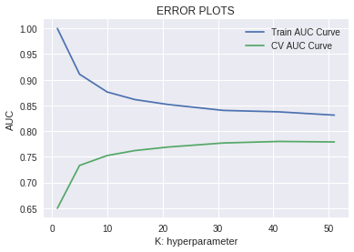

```python
# Please write all the code with proper documentation
from sklearn.metrics import roc_auc_score
train_auc= []
cv_auc= []
K = [1, 5, 10, 15, 21, 31, 41, 51]
for i in tqdm(K):
  neigh=KNeighborsClassifier(n_neighbors=i,algorithm="brute")
  neigh.fit(X_Train_BOW, Y_Train)
  y_train_pred=neigh.predict_proba(X_Train_BOW)[:,1]
  y_cv_pred=neigh.predict_proba(X_CV_BOW)[:,1]
  train_auc.append(roc_auc_score(Y_Train,y_train_pred))
  cv_auc.append(roc_auc_score(Y_CV, y_cv_pred))

plt.plot(K, train_auc, label='Train AUC Curve')
plt.plot(K, cv_auc, label='CV AUC Curve')
plt.legend()
plt.xlabel("K: hyperparameter")
plt.ylabel("AUC")
plt.title("ERROR PLOTS")
plt.show()
```

[figure not shown]

```python
# Distribution of K values
plt.scatter(K,cv_auc,label='Train AUC Curve')
plt.scatter(K,train_auc,label='CV AUC Curve')
plt.legend()
plt.xlabel("K: hyperparameter")
plt.ylabel("AUC")
plt.title("ERROR PLOTS")
plt.show()
```

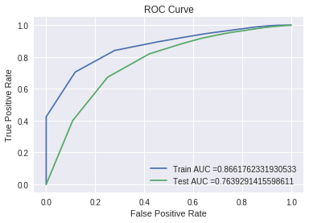

```python
from sklearn.metrics import roc_curve, auc

optimal_k_bow_BruteForce = 13
neigh_bow=KNeighborsClassifier(n_neighbors=optimal_k_bow_BruteForce,algorithm="brute")
neigh_bow.fit(X_Train_BOW, Y_Train)

train_fpr,train_tpr,thresholds = roc_curve(Y_Train, neigh_bow.predict_proba(X_Train_BOW)[:,1])
test_fpr, test_tpr, thresholds = roc_curve(Y_Test,  neigh_bow.predict_proba(X_Test_BOW )[:,1])
train_bow_acc =auc(train_fpr, train_tpr)
test_bow_acc = auc(test_fpr, test_tpr)

plt.plot(train_fpr, train_tpr, label="Train AUC ="+str(train_bow_acc))
plt.plot(test_fpr, test_tpr, label="Test AUC ="+str(test_bow_acc))
plt.legend()
plt.xlabel("False Positive Rate")
plt.ylabel("True Positive Rate")
plt.title("ROC Curve")
plt.show()
```

```
Test confusion matrix
```

[figure not shown]

```python
class_names= ['negative','positive']
print("Test confusion matrix")
array = confusion_matrix(Y_Test, neigh.predict(X_Test_BOW))

df_cm = pd.DataFrame(array, index = [i for i in class_names],columns = [i for i in class_names])
plt.figure(figsize = (10,7))
sns.heatmap(df_cm, annot=True,fmt="d")
plt.xlabel("Actual Label")
plt.ylabel("Predicted Label")
plt.show()
```

```
Train confusion matrix
```

[figure not shown]

```python
#https://stackoverflow.com/questions/35572000/how-can-i-plot-a-confusion-matrix
class_names= ['negative','positive']
print("Train confusion matrix")
array = confusion_matrix(Y_Train, neigh.predict(X_Train_BOW))

df_cm = pd.DataFrame(array, index = [i for i in class_names],columns = [i for i in class_names])
plt.figure(figsize = (10,7))
sns.heatmap(df_cm, annot=True,fmt="d")
plt.xlabel("Actual Label")
plt.ylabel("Predicted Label")
plt.show()
```

### [5.1.2] Applying KNN brute force on TFIDF, SET 2

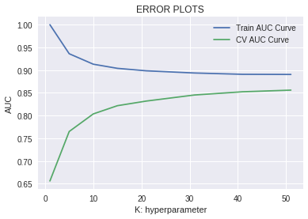

```python
# Please write all the code with proper documentation
from sklearn.metrics import roc_auc_score
train_auc= []
cv_auc= []
K = [1, 5, 10, 15, 21, 31, 41, 51]
for i in tqdm(K):
  neigh=KNeighborsClassifier(n_neighbors=i,algorithm="brute")
  neigh.fit(X_Train_TFIDF, Y_Train)
  y_train_pred=neigh.predict_proba(X_Train_TFIDF)[:,1]
  y_cv_pred=neigh.predict_proba(X_CV_TFIDF)[:,1]
  train_auc.append(roc_auc_score(Y_Train,y_train_pred))
  cv_auc.append(roc_auc_score(Y_CV, y_cv_pred))

plt.plot(K, train_auc, label='Train AUC Curve')
plt.plot(K, cv_auc, label='CV AUC Curve')
plt.legend()
plt.xlabel("K: hyperparameter")
plt.ylabel("AUC")
plt.title("ERROR PLOTS")
plt.show()
```

[figure not shown]

```python
# Distribution of K values
plt.scatter(K,cv_auc,label='Train AUC Curve')
plt.scatter(K,train_auc,label='CV AUC Curve')
plt.legend()
plt.xlabel("K: hyperparameter")
plt.ylabel("AUC")
plt.title("ERROR PLOTS")
plt.show()
```

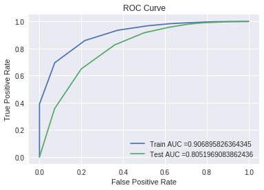

```python
optimal_k_tfidf_BruteForce = 13
neigh_bow=KNeighborsClassifier(n_neighbors=optimal_k_tfidf_BruteForce,algorithm="brute")
neigh_bow.fit(X_Train_TFIDF, Y_Train)

train_fpr,train_tpr,thresholds = roc_curve(Y_Train, neigh_bow.predict_proba(X_Train_TFIDF)[:,1])
test_fpr, test_tpr, thresholds = roc_curve(Y_Test,  neigh_bow.predict_proba(X_Test_TFIDF )[:,1])
train_tfidf_acc =auc(train_fpr, train_tpr)
test_tfidf_acc = auc(test_fpr, test_tpr)

plt.plot(train_fpr, train_tpr, label="Train AUC ="+str(train_tfidf_acc))
plt.plot(test_fpr, test_tpr, label="Test AUC ="+str(test_tfidf_acc))
plt.legend()
plt.xlabel("False Positive Rate")
plt.ylabel("True Positive Rate")
plt.title("ROC Curve")
plt.show()
```

```
Test confusion matrix
```

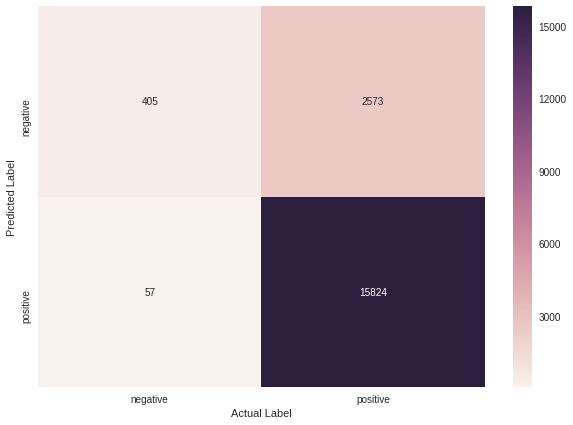

```python
class_names= ['negative','positive']
print("Test confusion matrix")
array = confusion_matrix(Y_Test, neigh.predict(X_Test_TFIDF))

df_cm = pd.DataFrame(array, index = [i for i in class_names],columns = [i for i in class_names])
plt.figure(figsize = (10,7))
sns.heatmap(df_cm, annot=True,fmt="d")
plt.xlabel("Actual Label")
plt.ylabel("Predicted Label")
plt.show()
```

```
Train confusion matrix
```

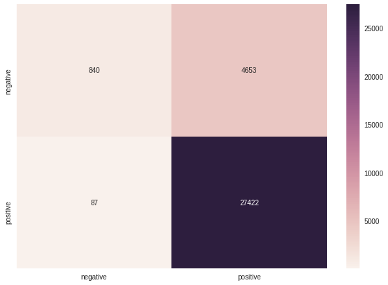

```python
class_names= ['negative','positive']
print("Train confusion matrix")
array = confusion_matrix(Y_Train, neigh.predict(X_Train_TFIDF))

df_cm = pd.DataFrame(array, index = [i for i in class_names],columns = [i for i in class_names])
plt.figure(figsize = (10,7))
plt.xlabel("Actual Label")
plt.ylabel("Predicted Label")
sns.heatmap(df_cm, annot=True,fmt="d")
plt.show()
```

### [5.1.3] Applying KNN brute force on AVG W2V, SET 3

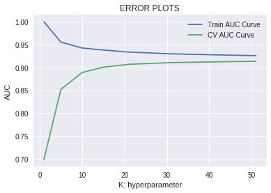

```python
# Please write all the code with proper documentation
from sklearn.metrics import roc_auc_score
train_auc= []
cv_auc= []
K = [1, 5, 10, 15, 21, 31, 41, 51]
for i in tqdm(K):
  neigh=KNeighborsClassifier(n_neighbors=i,algorithm="brute")
  neigh.fit(train_vectors, Y_Train)
  # roc_auc_score(y_true, y_score) the 2nd parameter should be probability estimates of t# not the predicted outputs
  y_train_pred=neigh.predict_proba(train_vectors)[:,1]
  y_cv_pred=neigh.predict_proba(cv_vectors)[:,1]
  train_auc.append(roc_auc_score(Y_Train,y_train_pred))
  cv_auc.append(roc_auc_score(Y_CV, y_cv_pred))

plt.plot(K, train_auc, label='Train AUC Curve')
plt.plot(K, cv_auc, label='CV AUC Curve')
plt.legend()
plt.xlabel("K: hyperparameter")
plt.ylabel("AUC")
plt.title("ERROR PLOTS")
plt.show()
```

[figure not shown]

```python
# Distribution of K values
plt.scatter(K,cv_auc,label='Train AUC Curve')
plt.scatter(K,train_auc,label='CV AUC Curve')
plt.legend()
plt.xlabel("K: hyperparameter")
plt.ylabel("AUC")
plt.title("ERROR PLOTS")
plt.show()
```

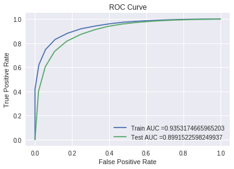

```python
optimal_k_avgw2vec_BruteForce = 19
neigh_bow=KNeighborsClassifier(n_neighbors=optimal_k_avgw2vec_BruteForce,algorithm="brute")
neigh_bow.fit(train_vectors, Y_Train)

train_fpr,train_tpr,thresholds = roc_curve(Y_Train, neigh_bow.predict_proba(train_vectors)[:,1])
test_fpr, test_tpr, thresholds = roc_curve(Y_Test,  neigh_bow.predict_proba(test_vectors )[:,1])
train_avgw2vec_acc =auc(train_fpr, train_tpr)
test_avgw2vec_acc = auc(test_fpr, test_tpr)

plt.plot(train_fpr, train_tpr, label="Train AUC ="+str(train_avgw2vec_acc))
plt.plot(test_fpr, test_tpr, label="Test AUC ="+str(test_avgw2vec_acc))
plt.legend()
plt.xlabel("False Positive Rate")
plt.ylabel("True Positive Rate")
plt.title("ROC Curve")
plt.show()
```

```
Test confusion matrix
```

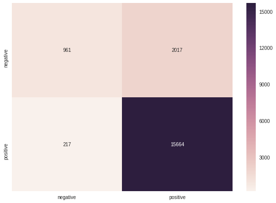

```python
class_names= ['negative','positive']
print("Test confusion matrix")
array = confusion_matrix(Y_Test, neigh.predict(test_vectors))

df_cm = pd.DataFrame(array, index = [i for i in class_names],columns = [i for i in class_names])
plt.figure(figsize = (10,7))
plt.xlabel("Actual Label")
plt.ylabel("Predicted Label")
sns.heatmap(df_cm, annot=True,fmt="d")
plt.show()
```

```
Train confusion matrix
```

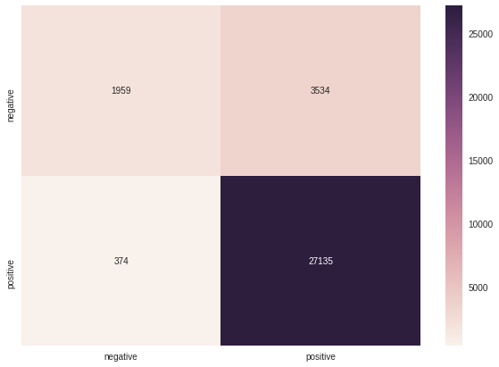

```python
class_names= ['negative','positive']
print("Train confusion matrix")
array = confusion_matrix(Y_Train, neigh.predict(train_vectors))

df_cm = pd.DataFrame(array, index = [i for i in class_names],columns = [i for i in class_names])
plt.figure(figsize = (10,7))
plt.xlabel("Actual Label")
plt.ylabel("Predicted Label")
sns.heatmap(df_cm, annot=True,fmt="d")
plt.show()
```

### [5.1.4] Applying KNN brute force on TFIDF W2V, SET 4

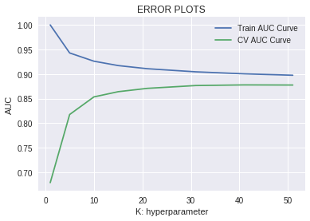

```python
# Please write all the code with proper documentation
from sklearn.metrics import roc_auc_score
train_auc= []
cv_auc= []
K = [1, 5, 10, 15, 21, 31, 41, 51]
for i in tqdm(K):
  neigh=KNeighborsClassifier(n_neighbors=i,algorithm="brute")
  neigh.fit(tfidf_w2v_Train, Y_Train)

  y_train_pred=neigh.predict_proba(tfidf_w2v_Train)[:,1]
  y_cv_pred=neigh.predict_proba(tfidf_w2v_CV)[:,1]

  train_auc.append(roc_auc_score(Y_Train,y_train_pred))
  cv_auc.append(roc_auc_score(Y_CV, y_cv_pred))

plt.plot(K, train_auc, label='Train AUC Curve')
plt.plot(K, cv_auc, label='CV AUC Curve')
plt.legend()
plt.xlabel("K: hyperparameter")
plt.ylabel("AUC")
plt.title("ERROR PLOTS")
plt.show()
```

[figure not shown]

```python
# Distribution of K values
plt.scatter(K,cv_auc,label='Train AUC Curve')
plt.scatter(K,train_auc,label='CV AUC Curve')
plt.legend()
plt.xlabel("K: hyperparameter")
plt.ylabel("AUC")
plt.title("ERROR PLOTS")
plt.show()
```

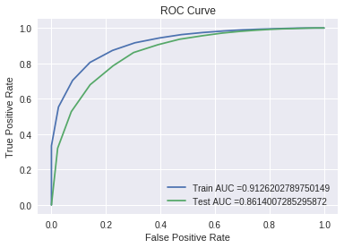

```python
optimal_k_tfidfw2v_BruteForce = 19
neigh_bow=KNeighborsClassifier(n_neighbors=optimal_k_tfidfw2v_BruteForce,algorithm="brute")
neigh_bow.fit(tfidf_w2v_Train, Y_Train)

train_fpr,train_tpr,thresholds = roc_curve(Y_Train, neigh_bow.predict_proba(tfidf_w2v_Train)[:,1])
test_fpr, test_tpr, thresholds = roc_curve(Y_Test,  neigh_bow.predict_proba(tfidf_w2v_Test )[:,1])
train_tfidfw2v_acc =auc(train_fpr, train_tpr)
test_tfidfw2v_acc = auc(test_fpr, test_tpr)

plt.plot(train_fpr, train_tpr, label="Train AUC ="+str(train_tfidfw2v_acc))
plt.plot(test_fpr, test_tpr, label="Test AUC ="+str(test_tfidfw2v_acc))
plt.legend()
plt.xlabel("False Positive Rate")
plt.ylabel("True Positive Rate")
plt.title("ROC Curve")
plt.show()
```

```
Test confusion matrix
```

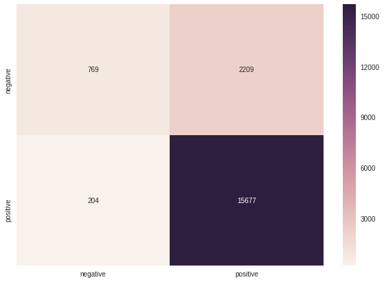

```python
class_names= ['negative','positive']
print("Test confusion matrix")
array = confusion_matrix(Y_Test, neigh.predict(tfidf_w2v_Test))

df_cm = pd.DataFrame(array, index = [i for i in class_names],columns = [i for i in class_names])
plt.figure(figsize = (10,7))
plt.xlabel("Actual Label")
plt.ylabel("Predicted Label")
sns.heatmap(df_cm, annot=True,fmt="d")
plt.show()
```

```
Train confusion matrix
```

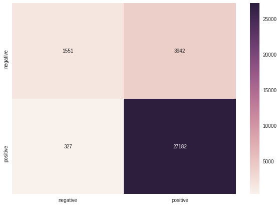

```python
class_names= ['negative','positive']
print("Train confusion matrix")
array = confusion_matrix(Y_Train, neigh.predict(tfidf_w2v_Train))

df_cm = pd.DataFrame(array, index = [i for i in class_names],columns = [i for i in class_names])
plt.figure(figsize = (10,7))
plt.xlabel("Actual Label")
plt.ylabel("Predicted Label")
sns.heatmap(df_cm, annot=True,fmt="d")
plt.show()
```

## [5.2] Applying KNN kd-tree

### [5.2.1] Applying KNN kd-tree on BOW, SET 5

```python
# Please write all the code with proper documentation
from sklearn.decomposition import TruncatedSVD
count_vect=CountVectorizer(min_df=10, max_features=500)

X_Train_BOW = count_vect.fit_transform(X_Train)
X_Test_BOW = count_vect.transform(X_Test)
X_CV_BOW = count_vect.transform(X_CV)

svd=TruncatedSVD(n_components=100)
#Convertin into Dense Vector
x_train_dense_BOW = svd.fit_transform(X_Train_BOW)
x_test_dense_BOW = svd.transform(X_Test_BOW)
x_cv_dense_BOW = svd.transform(X_CV_BOW)
```

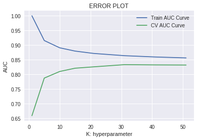

```python
# Applying KNN using KD-Tree
from sklearn.metrics import roc_auc_score
train_auc= []
cv_auc= []
K = [1, 5, 10, 15, 21, 31, 41, 51]
for i in tqdm(K):
  neigh=KNeighborsClassifier(n_neighbors=i,algorithm="kd_tree")
  neigh.fit(x_train_dense_BOW, Y_Train)
  # roc_auc_score(y_true, y_score) the 2nd parameter should be probability estimates of t# not the predicted outputs
  y_train_pred=neigh.predict_proba(x_train_dense_BOW)[:,1]
  y_cv_pred=neigh.predict_proba(x_cv_dense_BOW)[:,1]
  train_auc.append(roc_auc_score(Y_Train,y_train_pred))
  cv_auc.append(roc_auc_score(Y_CV, y_cv_pred))

plt.plot(K, train_auc, label='Train AUC Curve')
plt.plot(K, cv_auc, label='CV AUC Curve')
plt.legend()
plt.xlabel("K: hyperparameter")
plt.ylabel("AUC")
plt.title("ERROR PLOT")
plt.show()
```

[figure not shown]

```python
# Distribution of K values
plt.scatter(K,cv_auc,label='Train AUC Curve')
plt.scatter(K,train_auc,label='CV AUC Curve')
plt.legend()
plt.xlabel("K: hyperparameter")
plt.ylabel("AUC")
plt.title("ERROR PLOTS")
plt.show()
```

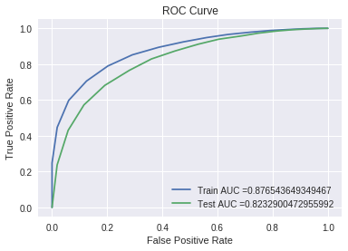

```python
optimal_k_bow_KdTree = 17
neigh_bow=KNeighborsClassifier(n_neighbors=optimal_k_bow_KdTree,algorithm="kd_tree")
neigh_bow.fit(x_train_dense_BOW, Y_Train)

train_fpr,train_tpr,thresholds = roc_curve(Y_Train, neigh_bow.predict_proba(x_train_dense_BOW)[:,1])
test_fpr, test_tpr, thresholds = roc_curve(Y_Test,  neigh_bow.predict_proba(x_test_dense_BOW )[:,1])
train_bow_kd_acc =auc(train_fpr, train_tpr)
test_bow_kd_acc = auc(test_fpr, test_tpr)

plt.plot(train_fpr, train_tpr, label="Train AUC ="+str(train_bow_kd_acc))
plt.plot(test_fpr, test_tpr, label="Test AUC ="+str(test_bow_kd_acc))
plt.legend()
plt.xlabel("False Positive Rate")
plt.ylabel("True Positive Rate")
plt.title("ROC Curve")
plt.show()
```

```
Test confusion matrix
```

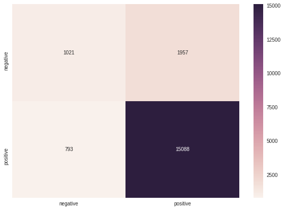

```python
class_names= ['negative','positive']
print("Test confusion matrix")
array = confusion_matrix(Y_Test, neigh.predict(x_test_dense_BOW))

df_cm = pd.DataFrame(array, index = [i for i in class_names],columns = [i for i in class_names])
plt.figure(figsize = (10,7))
plt.xlabel("Actual Label")
plt.ylabel("Predicted Label")
sns.heatmap(df_cm, annot=True,fmt="d")
plt.show()
```

```
Train confusion matrix
```

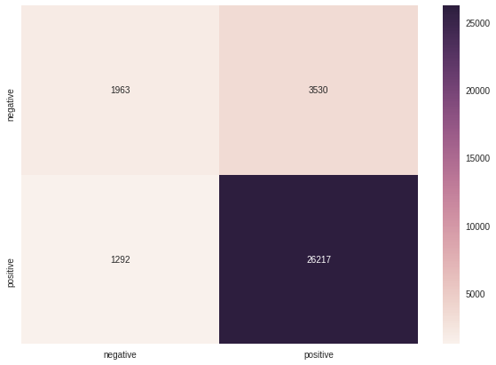

```python
class_names= ['negative','positive']
print("Train confusion matrix")
array = confusion_matrix(Y_Train, neigh.predict(x_train_dense_BOW))

df_cm = pd.DataFrame(array, index = [i for i in class_names],columns = [i for i in class_names])
plt.figure(figsize = (10,7))
plt.xlabel("Actual Label")
plt.ylabel("Predicted Label")
sns.heatmap(df_cm, annot=True,fmt="d")
plt.show()
```

```python
# Please write all the code with proper documentation
from sklearn.decomposition import TruncatedSVD
count_vect=CountVectorizer(min_df=10, max_features=500)

X_Train_TFIDF = count_vect.fit_transform(X_Train)
X_Test_TFIDF = count_vect.transform(X_Test)
X_CV_TFIDF = count_vect.transform(X_CV)

svd=TruncatedSVD(n_components=100)
#Convertin into Dense Vector
x_train_dense_TFIDF = svd.fit_transform(X_Train_TFIDF)
x_test_dense_TFIDF = svd.transform(X_Test_TFIDF)
x_cv_dense_TFIDF = svd.transform(X_CV_TFIDF)
```

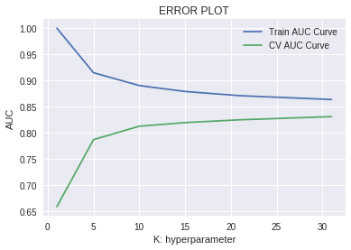

```python
# Applying KNN using KD-Tree
from sklearn.metrics import roc_auc_score
train_auc= []
cv_auc= []
K = [1, 5, 10, 15, 21, 31]
for i in tqdm(K):
  neigh=KNeighborsClassifier(n_neighbors=i,algorithm="kd_tree")
  neigh.fit(x_train_dense_TFIDF, Y_Train)

  y_train_pred=neigh.predict_proba(x_train_dense_TFIDF)[:,1]
  y_cv_pred=neigh.predict_proba(x_cv_dense_TFIDF)[:,1]
  train_auc.append(roc_auc_score(Y_Train,y_train_pred))
  cv_auc.append(roc_auc_score(Y_CV, y_cv_pred))

plt.plot(K, train_auc, label='Train AUC Curve')
plt.plot(K, cv_auc, label='CV AUC Curve')
plt.legend()
plt.xlabel("K: hyperparameter")
plt.ylabel("AUC")
plt.title("ERROR PLOT")
plt.show()
```

[figure not shown]

```python
# Distribution of K values
plt.scatter(K,cv_auc,label='Train AUC Curve')
plt.scatter(K,train_auc,label='CV AUC Curve')
plt.legend()
plt.xlabel("K: hyperparameter")
plt.ylabel("AUC")
plt.title("ERROR PLOTS")
plt.show()
```

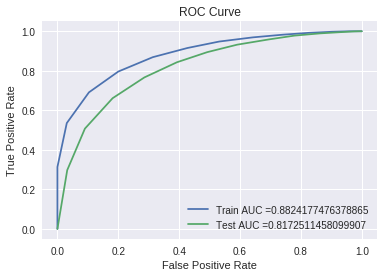

```python
optimal_k_tfidf_KdTree = 13
neigh_bow=KNeighborsClassifier(n_neighbors=optimal_k_tfidf_KdTree,algorithm="kd_tree")
neigh_bow.fit(x_train_dense_TFIDF, Y_Train)

train_fpr,train_tpr,thresholds = roc_curve(Y_Train, neigh_bow.predict_proba(x_train_dense_TFIDF)[:,1])
test_fpr, test_tpr, thresholds = roc_curve(Y_Test,  neigh_bow.predict_proba(x_test_dense_TFIDF )[:,1])
train_tfidf_kd_acc =auc(train_fpr, train_tpr)
test_tfidf_kd_acc = auc(test_fpr, test_tpr)

plt.plot(train_fpr, train_tpr, label="Train AUC ="+str(train_tfidf_kd_acc))
plt.plot(test_fpr, test_tpr, label="Test AUC ="+str(test_tfidf_kd_acc))
plt.legend()
plt.xlabel("False Positive Rate")
plt.ylabel("True Positive Rate")
plt.title("ROC Curve")
plt.show()
```

```
Test confusion matrix
```

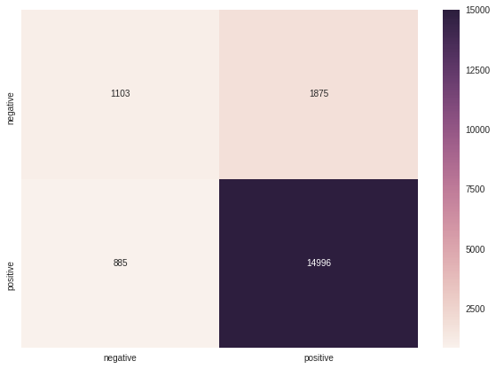

```python
class_names= ['negative','positive']
print("Test confusion matrix")
array = confusion_matrix(Y_Test, neigh.predict(x_test_dense_TFIDF))

df_cm = pd.DataFrame(array, index = [i for i in class_names],columns = [i for i in class_names])
plt.figure(figsize = (10,7))
plt.xlabel("Actual Label")
plt.ylabel("Predicted Label")
sns.heatmap(df_cm, annot=True,fmt="d")
plt.show()
```

```
Train confusion matrix
```

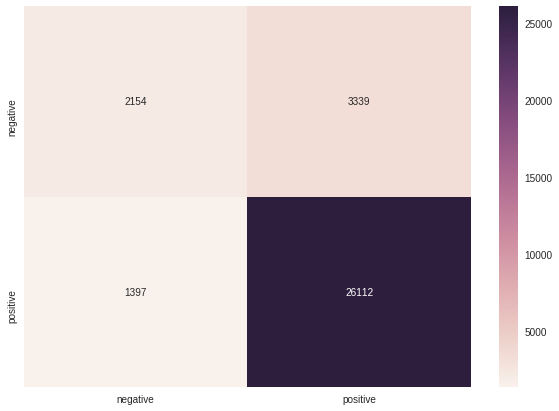

```python
class_names= ['negative','positive']
print("Train confusion matrix")
array = confusion_matrix(Y_Train, neigh.predict(x_train_dense_TFIDF))

df_cm = pd.DataFrame(array, index = [i for i in class_names],columns = [i for i in class_names])
plt.figure(figsize = (10,7))
plt.xlabel("Actual Label")
plt.ylabel("Predicted Label")
sns.heatmap(df_cm, annot=True,fmt="d")
plt.show()
```